# BS 1515 Lecture 1: Sets, Inequalities, and Equations

Sergey V. Popov

2026-09-21

# Economics

We as economists:

- Describe what people do with the allocation of resources (empirics)
- Develop stories about why they behave that way (theory)

Both of these require math:

- why statistical methods applied to data produce meaningful results (empirics)
- why assumptions about individual behavior lead to predictions (theory)

Math is how economists argue.

# Math

Math studies what follows logically from precise assumptions.

- Agents behaving optimally: What’s an agent? How do they choose? What’s the difference between optimal and not optimal? How do agents interact?
- Things being random: what things? If one thing happened, can another thing happen at the same time? If one thing happened, does that make another thing more likely?
- Countries developing: what resources do they use? How are they combined? why do different countries get drastically different results from similar resources?

Things we study today will apply to other parts of this course, and will be useful for other courses as well.

# Example: Liberation Day

April 2, 2025: Trump imposed tariffs on all other countries

- minimum 10%
- higher rates for countries with a large trade deficit in goods, services trade ignored
- suggested to abolish income tax, use tariff income instead

Questions:

- How is it supposed to work?
- Need to think about foreign producers and consumers
- Need to think about domestic producers and consumers
- Where does the tax formula come from?

Need to argue precisely! (or cause markets to collapse)

# Sets

The fundamental object of mathematics is a *set*, containing *elements*.

- Set of numbers $\{1,2,3\}$.
- Set of students $\{\text{John},\text{Megan},\text{Dylan},\text{Susie}...\}$.
- Set of students in this classroom.
- Set of students who are supposed in this classroom.

An object can be *in* a set ($a \in A$) or *not in* ($a \not \in A$).

If all elements of set $B$ are in set $A$, $B$ is a *subset* of $A$: $B \subseteq A$; $A$ is a *superset* of $B$.

If there are elements in $A$ that are not in subset $B$, $B$ is a *proper subset* of $A$: $B \subset A$, and $A$ is a *proper superset* of $B$.

*Empty set* containing no elements is $\emptyset=\{\}$. *Singleton* set contains one element.

# Example

When shopping, people have *budgets* (say £100/week) and decide on a shopping basket

- set of all shopping baskets
- set of affordable shopping baskets (the budget set)

When choosing where to study, pupils choose

- the set of university to apply - rules restrict it
- school to attend

When deciding on a stock/bond portfolio

- proportions of assets
- amount of money to invest

# Operations on sets

We can manipulate sets:

$\land$ means AND. $\lor$ means OR. $\Rightarrow$ means part on the left implies part on the right. $\Leftrightarrow$ means when left part holds, right part holds, and vice versa.

Prove: $A \setminus B = A \cap \neg B$.

Prove: $A \cap B \subseteq A \cup B$. When can we claim that $A \cup B \subseteq A \cap B$?

Prove: $A \cup B = (A \cap B) \cup (A \setminus B) \cup (B \setminus A)$.

# Euler-Venn diagram

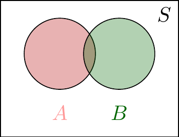

*Space* $S$ is important!

# Exercises for Sets

Consider a standard 52-cardsdeck. A poker hand is 5 cards drawn from this deck at random. Verify claims:

- The set of poker hands featuring three of a kind is a subset of the set of poker hands featuring a pair.
- The set of poker hands featuring two pairs is a subset of the set of poker hands featuring a pair.
- The set of poker hands featuring a straight (cards in sequence of rank ignoring suits) and the set of poker hands featuring a pair do not overlap.
- The set of poker hands featuring a flush (5 cards of the same suit) and the set of poker hands containing a straight do not overlap.
- The set of poker hands containing a full house is an intersection of hands containing three of a kind and hands that contain a pair.

# Functions

*Function* $f:A\rightarrow B$ is a rule that gives exactly one element of $B$ for every element of $A$.

$f(x)=2x+3$ is an example of $f:\mathbb{R}\rightarrow \mathbb{R}$.

$F(x,y)=0$ can define an *implicit function* of $y(x)$ or of $x(y)$.

- Not always a “true” function that gives you $y$ of $x$!
- $F(x,y)=y-2x-3=0$ gives you a function $y=2x+3$.
- $F(x,y)=y^2-x=0$ gives you two values of $y$ for each value of $x\geq 0$.
- We’ll come back to these later.

*One-to-one* function: for each element of $B$ you get a distinct element of $A$.

*Onto* function: for each $b\in B$ there is an $a\in A$ that gives $f(a)=b$.

If both, function is *invertible*. $f(x)=x^2$ is invertible when defined on $\mathbb{R}_+\rightarrow \mathbb{R}_+$ but not if defined on $\mathbb{R}\rightarrow \mathbb{R}$.

# Examples of Functions

- $f(x)=x^2$ is invertible for $x \in [0,+\infty)$ but not for $x\in(-\infty,+\infty)$.
- $f(x)=e^x$ is invertible, $g(y)=\ln(y)$ is the inverse.
- $f(x)=a+bx$ is invertible if $b\not =0$.

Why does invertibility matter?

- If we have a function from unobservables to data, we want to infer unobservables from data

# Real numbers

*Naturals* $\mathbb{N}=\{1,2,3,\ldots\}$

*Integers* $\mathbb{Z}=\mathbb{N}\cup\{0\}\cup(-\mathbb{N})$

*Rationals* $\mathbb{Q}=\{a/b: a, a\in \mathbb{Z}, b\in \mathbb{N}\}$

*Reals* $\mathbb{R}$ are different: includes $\mathbb{Q}$ and *irrationals* such as $\sqrt{2}$. Reals is a set that has a *separability* property that $\forall X,Y\subset A \text{ such that }\forall x \in X \text{ and }\forall y \in Y x<y \Rightarrow \exists z\in A :x\leq z\leq y$.

Notice that $\mathbb{Q}$ does not have this property: $X=\{t\in\mathbb{Q}:t\leq 0 \text{ or } t^2<2\}$ and $Y=\{t\in\mathbb{Q}:t>0,\ t^2>2\}$ are not separated by any $z \in \mathbb{Q}$ (the only number between them is $\sqrt{2}$)!

*Euclidean space* $\mathbb{R}^N$ for $N\in \mathbb{N}$.

*Metric*: way of measuring distance in space, a function $d(x,y)$. For reals, could be $d(x,y)=|x-y|$. Metric is a feature of the space.

Metrics must be

1. positive: $d(x,y)\geq 0$;
2. symmetric: $d(x,y)=d(y,x)$;
3. $d(x,y)\leq d(x,z)+d(z,y)$ - triangular inequality; and
4. $d(x,x)=0$.

# Important Reals

$\pi=3.14159...$ is not rational.

$e=2.7182828...$ is not rational.

Neither can be represented as a solution to a polynomial equation with integer coefficients, or *transcendental*.

# Countable Sets

Set is *finite* if it is empty or there is an invertible function from the set to $\{1,2,\ldots,n\}$ for some $n\in\mathbb{N}$.

Set is *countable* if it is finite or there is an invertible function from the set to $\mathbb{N}$.

Set is *uncountable* if it is not countable.

Prove: $\mathbb{Q}$ is countable. (hard!)

Prove: $\mathbb{R}$ is uncountable. (hard!)

# Open and Closed

Open $\varepsilon$-ball around $x$: $B_\varepsilon(x)=\{t:d(x,t)<\varepsilon\}$.

A set $A$ is *open* in space *S* with metric $d(x,y)$ if $\forall x \in A \exists \varepsilon>0: B_{\varepsilon}(x) \subseteq A$.

A set $A$ is *closed* if complement of $A$, $\neg A=S\setminus A$, is open.

Prove: A union of open sets is open.

Prove: An intersection of closed sets is closed.

Prove: A space $S$ is both closed and open in $S$.

Prove: An empty set $\emptyset$ is both closed and open in $S$.

# Order and Intervals

Some spaces are *ordered*: there is a relation $R(x,y)$, TRUE or FALSE for each $x,y \in S$, that is transitive ($R(x,y)$ and $R(y,z)$ imply $R(x,z)$). It is a *complete* order if for any $x,y$ at least one of $R(x,y)$, $R(y,x)$ holds; otherwise it is *partial*.

- $\mathbb{R}$ is ordered with respect to “bigger than” order $>$
- $\mathbb{R}^2$ is partially ordered with respect to $>(x,y)=TRUE$ if $x_1>y_1\land x_2>y_2$.
- If you have a *utility function* over your *consumption bundles*, your preference relation is complete and ordered.

Interval $(a,b) \subseteq S$ is $\{x:a<x<b\}$. Interval $[a,b] \subseteq S$ is $\{x:a\leq x \leq b\}$.

Prove: Interval $(a,b)$ in $\mathbb{R}$ is open.

Prove: Interval $[a,b]$ in $\mathbb{R}$ is closed.

Prove: Interval $(a,b]$ in $\mathbb{R}$ is neither open nor closed.

# Convex set

Take two points in a set $A$, $a$ and $b$. Take $c(\lambda)=\lambda a+(1-\lambda)b$ for $\lambda\in(0,1)$.

- Can you always do this? What do you need to take a point like this?

If for every $a,b, \lambda$ point $c(\lambda)$ is in set $A$, this set is *convex*.

Prove: an intersection of two convex sets is convex.

Prove: empty set is convex.

Prove: any singleton is convex.

Prove: $\mathbb{R}^N$ is convex.

# Equalities and Inequalities

Consider a set

$$\left\{(x,y)\in\mathbb{R}^2:x+2y<3\right\}$$

Plot it:

[figure not shown]

Is that an open set?

# System of Inequalities

Now we have two inequalities:

$$\left\{(x,y)\in\mathbb{R}^2:x+2y<3,x+y>2\right\}$$

Plot it:

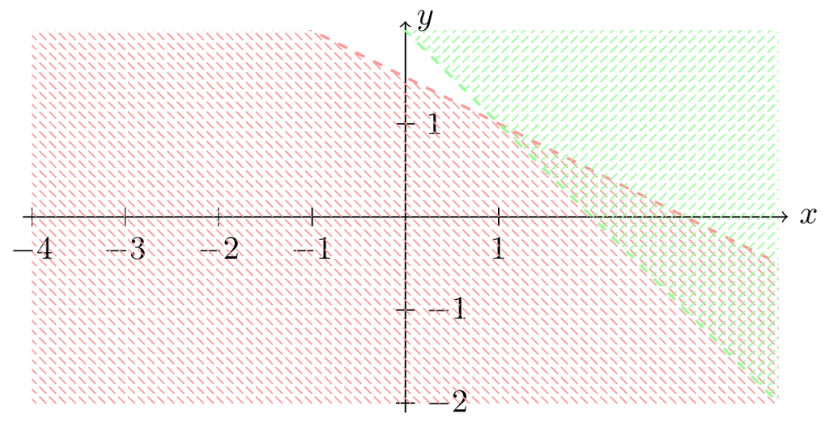

Is that an open set?

# Equation

Consider a set

$$\left\{(x,y)\in\mathbb{R}^2:x+2y=3\right\}$$

Plot it:

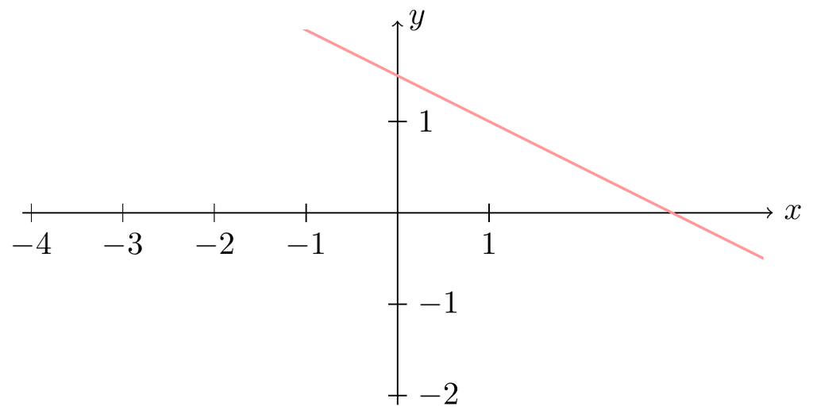

Is that an open set?

# System of Equations

Now we have two equations:

$$\left\{(x,y)\in\mathbb{R}^2:x+2y=3,x+y=2\right\}$$

Plot it:

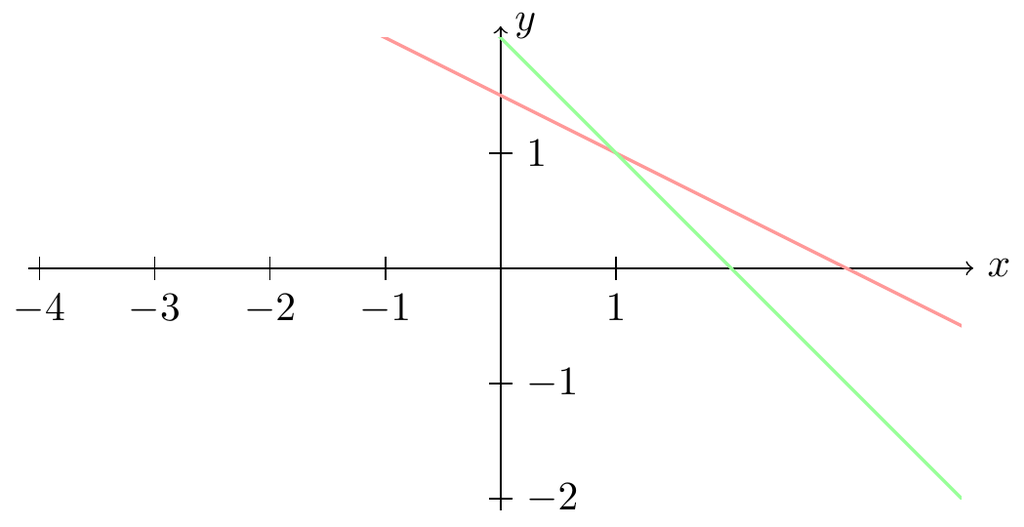

Generically - do you have to have one intersection? What if equations are not linear?

# Example: Supply and Demand

Let Supply be $Q=3p-20$ and Demand be $Q=60-p$. What is the equilibrium price?

Answer 1: $3p-20=60-p$ so $4p=80$ and $p=20$ and $Q=60-20=40$.

Answer 2: solve a system of $Q=60-p$ and $Q=3p-20$.

Now you know: how do we know there is a solution?

# Continuous Functions

A function $f:D\rightarrow E$ is *continuous* at $x$ if for every $\varepsilon>0$ there is a $\delta>0$ such that for all $x'\in B_\delta(x)$ it holds that $f(x') \in B_\varepsilon (f(x))$.

Intermediate Value Theorem*: If $f(\cdot)$ is continuous on $[a,b]$, then for every value $c$ between $f(a)$ and $f(b)$ there is an $x\in[a,b]$ such that $f(x)=c$.

Important part: $f(\cdot)$ is *continuous*: no jumps!

Automatic for linear functions, but not generic.

Good news for us: can establish that an equation/system of equations has a solution, but not necessarily uniqueness.

# Maximum Theorem

Let $f(x,y)$ be continuous function with $x$ on a compact set $X$. Then $\max_x f(x,y)$ exists and is continuous in $y$.

Extends to multiple dimensions and constraints.

*Compact* means every covering by open sets has a finite subcovering. Closed and bounded in $\mathbb{R}^N$, but not enough for $\mathbb{R}^\infty$!

Good news for us: people maximizing utility will choose something as long as their constraints make sense.

# Summary

This week: - We introduced the concepts of sets, spaces, and functions - We talked about how are they related to equations and systems

Next week: - Multi-dimensional spaces - Linear functions and systems - Matrices and vectors